## title: "Morse Oscillator" date: "2026-4-16" categories: [Quantum Mechanics]

# Vibrational Anharmonicity in Diatomic Molecule

## Beyond The Harmonic Oscillator

Let's now consider two ways in which the vibrational structure of "real molecules" is more complicated than what we've seen for the harmonic oscillator.

## Anharmonicity

First, real vibrational motions involve "anharmonicity", e.g. Their potential deviate from perfect harmonic oscillator quadratic potential energy surfaces. We've already touched on this by looking at the Morse Potential.

[figure not shown]

$$\mbox{Figure.The Morse Potential (blue) and harmonic oscillator potential (green)}$$

The harmonic oscillator is a reasonable approximation of this potential near the equilibrium geometry, but deviates substantially for $x$ far from the center of the well. Correspondengly, the vibrational levels of the Morse potential will deviate from those of the HO model. Note that the Morse potential levels grow closer together as energy increases.

## Limitations of the Harmonic Oscillator Model for Molecular Vibrations

The harmonic oscillation is a great approximation of a molecular vibration, but has key limitations:

- Due to equal spacing of energy, all transitions occur at the *same* frequency (i.e. single line spectrum). However experimentally many lines are often observed (called overtones).
- The harmonic oscillator does not predict bond dissociation, you cannot break it no matter how much energy is introduced.

# Morse Oscillator Breakdown

The Morse oscillator is a model for a particle in a one-dimensional anharmonic potential energy surface with a dissociative limit at infinite displacement. It is commonly used for describing the spectroscopy of diatomic molecules and anaharmonic vibrational dynamics, and most of its properties can be expressed through analytically expressions. The Morse potential is

$$V(x) = D_e[1-e^{-\alpha x}]^2 \tag{1}$$

where $x = (r - r_0)$, $D_e$ sets the depth of the energy minimu at $r=r_0$ relative to the dissociation limit as $r \rightarrow \infty$, and $\alpha$ sets the curvature of the potential. If we expand $V$ in powers of $x$ about $x=0$, the parameter $\alpha = \sqrt{k_e /2D_e}$ and $k_e = \left(\frac{d^2 V}{dx^2} \right)_e$ is the bond force constant at the bottom of the potential well.

The Morse oscillator Hamiltonian for a diatomic molecule of reduced mass *mR* bound by the potential is

$$H = \frac{p^2}{2m_R} + V(x)$$

and has the eigenvalues

$$E_v = \hbar \omega_0 \left[\left(v + \frac{1}{2} \right) - x_e \left(v + \frac{1}{2} \right)^2 \right] \quad v =0, \ 1, 2, \ 3, \ldots \tag{2}$$

where

- $v$ is vibrational quantum number.
- $\omega_0 = \sqrt{2 D_e \alpha^2 / m_R}$ is the fundamental frequency.
- $x_e = \frac{\hbar \omega_0}{4 D_e}$ is the harmonic constant.
- The frequency $\omega_0$ is equivalent to equating the harmonic for constant $\mathcal{K} = (\partial^2 V/ \partial x^2)_{x=0}$ with $m_R \omega_0^2$.

The harmonic oscillator approximation is convenient to use for diatomic molecules with quantized vibrational energy levels given by the following equation:

$$E_v = \left ( v + \frac{1}{2} \right) \omega_e$$

The new energy levels of this *anharmonic* potential can be found using *perturbation theory*. We will just writw down the result here that we find higher-order corrections to the energy according to:

$$G(v) = \omega_e \left(v + \frac{1}{2} \right) - \omega_e x_e \left( v + \frac{1}{2} \right)^2 + \omega_e y_e \left(v + \frac{1}{2} \right)^3 + \ldots \tag{3}$$

where $\omega_e$ is the anharmonic oscillator frequency, and $x_e$ is the *anharmonic constant*, which is typically much smaller than $\omega_e$.

While it masy seem that the harmonic oscillator and the anharmonic oscillator are closely related, this is in fact not the case. The difference in the wavefunctions lead to a breakdown of selection rules, specifically, $\Delta v = \pm 1$ selection rule can not be applied, and higher order terms must be accounted in the energy calculations.

On other note is that anharmonicity also changes the selection rules for IR transitions. For absorption of IR light, we can now have:

$$\Delta v = +1, \ +2, \ +3, + \ldots$$

where $\Delta v = +1$ are *fundamental transition* and $\Delta v = +2, \ +3, + \ldots$ are called *overtones*, and can occur but are much weaker in intensity than the *fundamental*. Overtone transitions are not always observed, especiall in larger molecules, because the transitions become weaker with increasing $Delta n$.

## Overtones

Based on the harmonic oscillator approximation, the energy of the overtone transition would be $v$ times larger than the energy of the fundamental transition frequency, but the *anharmonic oscillator* calculations show that the overtones are less than a multiple of the the fundamental frequency. This is demonstrated wuth the vibration of the diatomic in the gas phase:

$\mbox{Table 1. HCl vibrational spectrum}$

| Transition | Term | $v_{obs} \ [cm^{-1}]$ | $v_{Harmonic} \ [cm^{-1}]$ | $v_{Anharmonic} \ [cm^{-1}]$ |
| --- | --- | --- | --- | --- |
| $0 \rightarrow 1$ | fundamental | 2,885.9 | 2,885.9 | 2,885.3 |
| $0 \rightarrow 2$ | first overtone | 5,668.0 | 5,771.8 | 5,665.0 |
| $0 \rightarrow 3$ | second overtone | 8,347.0 | 8,657.7 | 8,339.0 |
| $0 \rightarrow 4$ | third overtone | 10,923.1 | 11,543.6 | 10,907. 4 |
| $0 \rightarrow 4$ | fourth overtone | 13,396.5 | 14,429.5 | 13,370 |

We can see from Table 1. that the anharmonic frequencies correspond much better with the observed frequencies, especially as the vibrational levels increase.

## The Morse oscillator $Schr\ddot{o} dinger$ equation

Solving the $Schr\ddot{o}dinger$ with the Morse oscillator is not trivial, but can be done analytically in terms of associated **Laguerre polynomials**.

$$\psi (v) = N_v z^{\lambda - v - \frac{1}{2}} e^{-z / 2} L_v^{2 \lambda - 2v - 1} (z) \quad [in \ cm^{-1}] \tag{4}$$

where

- $N_v = \sqrt{\frac{n!(2\lambda - 2v - 1)a}{\Gamma (2 \lambda - v)}}, \quad \lambda = \frac{\sqrt{2mD_e}}{a\hbar}$ is normalization constant.
- $\mathcal{L}_v^(\alpha) = \frac{z^{- \alpha} e^z}{v !} \ \frac{d^v}{dz^v} (z^{v + \alpha} e^{-z}), \quad z= 2\lambda e^{-x}$ is a *generalized Laguerre Polynomial*.
- $v = 0, \ 1, \ 2, \ 3, \ldots, \left[ \lambda - \frac{1}{2} \right]$

## Preliminaries

`scipy.constants`: is the package provides the internationally agreed standard values and uncertainties for physical constants include a large number of algorithms for calculating functions that appear in science.

$$\mbox{Table 1. Physical constants} \ \mathtt{scipy.constant}$$

| Constant string | Variable | Value | Units |
| --- | --- | --- | --- |
| Planck constant | h | 6.62606957e-34 | J s |
| Speed of light in vacuum | c | 299792458.0 | m s-1 |
| Avogadro constant | N_A | 6.02214129E+23 | mol-1 |
| Atomic mass | u | 1.6605390666e-27 | kg |

## E24.1 Inferring Morse Parameters from a vibrational spectrum

The vibrational spectrum of the $HCl$ molecule shows a fundamental band at $2,885.9 \ cm^{-1}$ and the first overtone band at $5,668.0$. This information can be used to estimate the Morse parameters, $D_e$ and $\alpha$, and hence the good strength and maximum vibrational level.

**Solution**:

1. Observe bands to estimate the parameters $\omega_e$ and $\omega_e x_e$. The fundamental vibrational band, corresponding to the transition $v = 0 \rightarrow 1$, occurs at a wavenumber given by

$$v_{0 \rightarrow 1} = G(1) - G(0) = \omega_e - 2\omega_e x_e$$

*Overtone bands*, for which $\Delta > 1$ are predicted to be observed at wavenumber

$$v_{0 \rightarrow v} = G(v) - G(0) = \omega_e v - \omega_e x_e v(v+1)$$

The observe bands of HCl,

$$\begin{align} v_{0 \rightarrow 1} &= \omega_e - 2 \omega_e x_e = 2885 \ cm^{-1}, \\ v_{0 \rightarrow 2} &= 2\omega_e - 6\omega_e x_e = 5668 \ cm^{-1} \end{align}$$

Therefore

$$\begin{align} \omega_e x_e &= \frac{1}{2} (2 v_{0 \rightarrow 1} - v_{0 \rightarrow 2}), \\ \omega_e &= v_{0 \rightarrow 1} + 2 \omega_e x_e \end{align}$$

2. Compute the Morse oscillator model

$$\begin{align} D_e &=\frac{\omega^2}{4 \omega_e x_e} \ \mbox{and} \\ \alpha &=2 \pi c \omega_e \sqrt{\frac{\mu}{2 D_e}} \end{align}$$

where $\mu$ is the reduced mass of the molecule.

4. Calculate the bond strength from the ground state. From eq.1 the ground state (or zero-point) energy is

$$ E_0 = \frac{1}{2} \hbar \omega_0 (1 - \frac{1}{2} x_e)$$

The proper harmonic expressions are obtained from the above for the Morse oscillator by setting $D_e \rightarrow \infty$ or $x_e \rightarrow 0$.

5. Calculate the highest energy level ($v_{max}$)

The vibrational energy levels converge with increasing quantum number, $v$, the highest energy level, $v_max$ is given by the condition

$$\begin{align} \frac{d G(v)}{dv} & = 0 \\ \omega_e - 2 \omega_e x_e(v_{max} + \frac{1}{2}) & =0 \\ v_{max} &=\frac{\omega_e}{2 \omega_e x_e} - \frac{1}{2} \end{align}$$

6. Plotting the Morse oscillator potential.

```python
# 1. The parameter we and wexe
nu_0_1, nu_0_2 = 2885, 5668
wexe = (2 * nu_0_1 - nu_0_2) / 2
we = nu_0_1 + 2 * wexe

print(f'we = {we} cm-1, wexe = {wexe} cm^-1')
```

```
we = 2987.0 cm-1, wexe = 51.0 cm^-1
```

```python
# 2. Compute the Morse oscillator model
import numpy as np
from scipy.constants import h, c, N_A, u
import matplotlib.pyplot as plt

# Dissociation energy measured from the potential minimum, cm-1
De = we**2 / 4 / wexe

# Reduced mass of (1H) (35.5Cl)
mu = 1 * 35.5 / (1 + 35.5) * u

# Compute everything to SI units in calculating a: De / J = hc.De / cm-1
a = 2 * np.pi * (c * 100) * we * np.sqrt(mu / 2 / (De * h * (c * 100)))

# Convert a from m-1 to A-1
a *= 1.e-10

print(f'De = {De:.0f} cm-1, a = {a:.1f} A-1')
```

```
De = 43736 cm-1, a = 1.7 A-1
```

The Morse parameter, $D_e$, is the dissociation energy measured from the potential minimum. The bond strength is the energy required to dissociate the molecule from its ground state ($v =0$, with energy $G(0) = \frac{1}{2} \omega_e - \frac{1}{4} \omega_e x_e)$.

```python
E0 = we / 2 - wexe / 4
D0 = De - E0

# Convert dissociation energy, D0, to kj.mol-1
bond_strength = D0 * h * (c * 100) * N_A / 1000
print(f' CO bond strength = {bond_strength:.0f} kj.mol-1')
```

[output not shown]

```python
# Calculate the highest energy level ($v_{max}$)

vmax = int(we / 2 / wexe - 0.5)
print(f'vmax = {vmax}')
```

```
vmax = 28
```

To plot the potential energy curve and energy levels, create an array of bind displacement, $x= r - r_e$ and use the Morse oscillator formula $V(x)$:

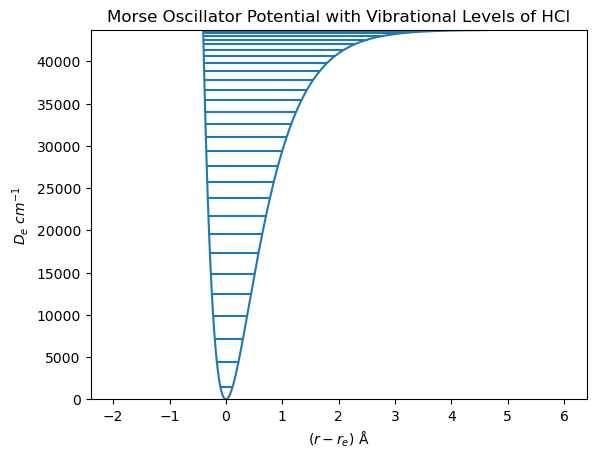

```python
# 6.  Plotting the Morse oscillator potential.

# Grid of bond displacement values, x = r - re, in Angstrom.
x = np.linspace(-2, 6, 3000)

# Morse Oscillator potential
V = De * (1 - np.exp(-a*x))**2

# Plot the Morse Oscillator
plt.plot(x, V)
plt.xlabel(r'$(r - r_e) \ \mathrm{\AA}$')
plt.ylabel(r'$D_e  \ cm^{-1}$')
plt.ylim(0, De)
plt.title("Morse Oscillator Potential with Vibrational Levels of HCl")

# Arrays of vibrational quantum number nd corresponding energy.
v = np.arange(0, vmax+1, 1, dtype=int)
Ev = np.array([we * (v+0.5) - wexe * (v + 0.5)**2])

# Classical turning points
xm = - np.log(1 + np.sqrt(Ev / De)) / a
xp = - np.log(1 - np.sqrt(Ev/ De)) / a

# Plot teh energy level as horizontal lines between xm and xp at Ev
plt.savefig('Morse Oscillator Potential with Vibrational Levels.svg', bbox_inches='tight')
plt.hlines(Ev, xm, xp)
```

# Conclusion

- The Morse oscillator is a bridge of the gap between idealized theory and real molecular behavior.
- Undertanding vibrational sepctroscopy, chemical bonding, and molecular dissociation are very important.